# Lab #3

Julian Stanley

23 February 2018

### Introductory Material

```r
my.vars <- data.frame(a1 = 1:10, a2 = 11:20, b1 = 21:30, b2 = 31:40)
my.means <- sapply(my.vars, FUN = mean)
my.means
```

```
##   a1   a2   b1   b2
##  5.5 15.5 25.5 35.5
```

```r
# Get the mean of the first and third columns
my.first.means <- sapply(my.vars[,c(1,3)], FUN = mean)
my.first.means
```

```
##   a1   b1
##  5.5 25.5
```

```r
my.mat <- cbind(my.means[c(1,3)], my.means[c(2,4)])
my.mat
```

```
##    [,1] [,2]
## a1  5.5 15.5
## b1 25.5 35.5
```

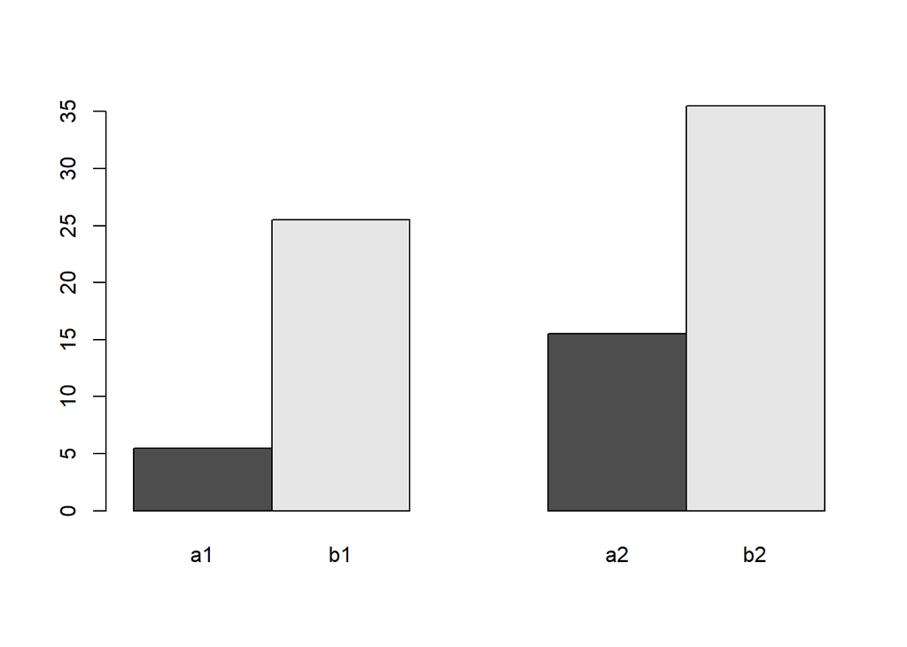

```r
barplot(my.mat,beside = TRUE, names.arg = c("a1", "b1", "a2", "b2"))
```

### Exercise 1

```r
my.mat2 <- cbind(my.means[c(1,2)], my.means[c(3,4)])
my.mat2
```

```
##    [,1] [,2]
## a1  5.5 25.5
## a2 15.5 35.5
```

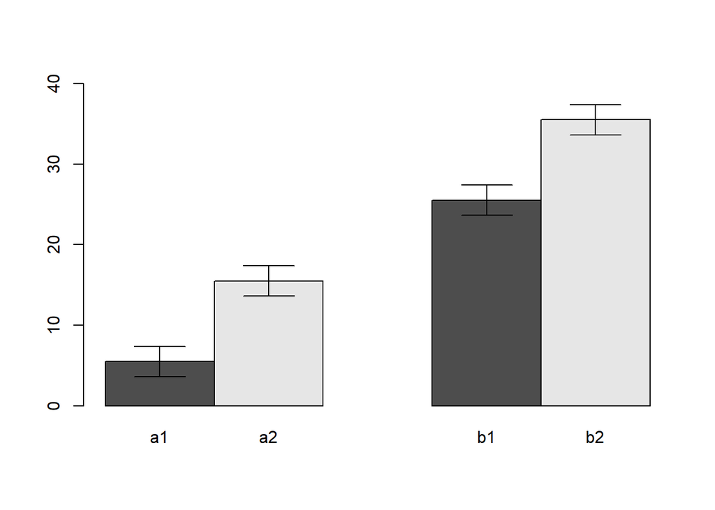

```r
# Function that computes 95 percent confidence intervals
conf95 <- function(x) {
  return(1.96*(sd(x) / sqrt(length(x))))
}

# upper conf interval
my.conf_upper = my.means + sapply(my.vars, FUN = conf95)
my.conf_lower = my.means - sapply(my.vars, FUN = conf95)

bar1 <- barplot(my.mat2,beside = TRUE, names.arg = c("a1", "a2", "b1", "b2"), ylim = c(0,40))
arrows(x0 = bar1, y0 = my.conf_lower , x1 = bar1, y1 = my.conf_upper, angle = 90, code = 3)
```

```r
my.sums <- colSums(my.vars)
```

```r
# Create some data
my.table <- cbind(c(5, 21), c(65, 56))
my.table
```

```
##      [,1] [,2]
## [1,]    5   65
## [2,]   21   56
```

```r
f.test <- fisher.test(my.table)
f.test
```

```
##
##  Fisher's Exact Test for Count Data
##
## data:  my.table
## p-value = 0.002012
## alternative hypothesis: true odds ratio is not equal to 1
## 95 percent confidence interval:
##  0.05724247 0.61347267
## sample estimates:
## odds ratio
##  0.2072082
```

```r
# Extract the p-value
f.test$p.value
```

```
## [1] 0.002012266
```

## Task 1

### Problem 1

Setup: Fields with alternating GMO and non-GMO plants. Blind: neither the researcher running the experiment nor the person planting the seeds know which seeds are GMO and which are non-GMO.

Controls: Need a positive control. I would also plant some seeds with a known-low gemination rate and a known-high germination rate as positive and negative controls.

Replication: Use multiple fields and as many seeds as possible

### Problem 2

```r
d1 <- read.csv("http://faraway.neu.edu/data/lab3_dataset1.csv")
```

### Problem 3

```r
colnames(d1)
```

```
## [1] "trial"              "gmo.germinated"     "wild.germinated"
## [4] "gmo.notgerminated"  "wild.notgerminated"
```

```r
# Seeds germinated vs seeds that failed to germinate in GMO and wild type

seed.means <- sapply(d1[2:5], FUN = sum)
seed.means
```

```
##     gmo.germinated    wild.germinated  gmo.notgerminated
##                809                257                191
## wild.notgerminated
##                743
```

```r
seeds.conf.lower <- seed.means - sapply(d1[2:5], FUN = conf95)

seeds.conf.upper <- seed.means +  sapply(d1[2:5], FUN = conf95)
```

### Problem 4

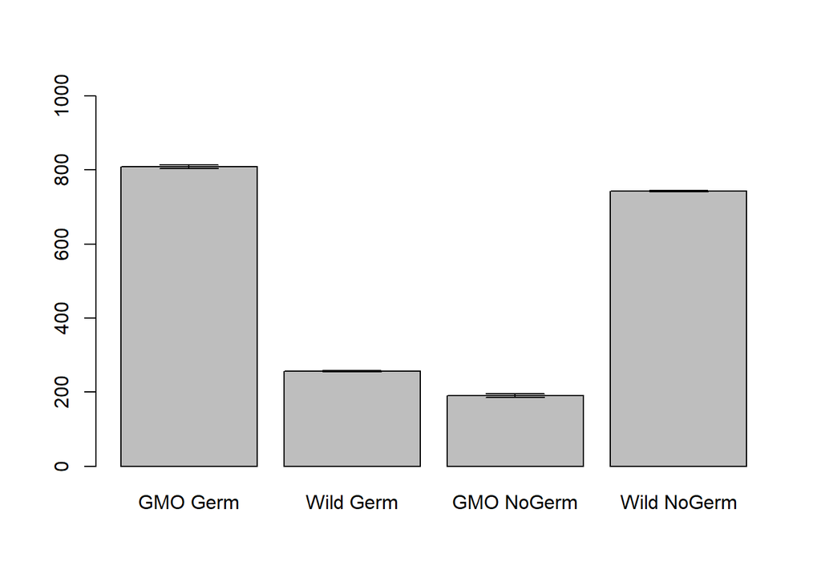

```r
seedsBar <- barplot(seed.means, names.arg = c("GMO Germ", "Wild Germ", "GMO NoGerm", "Wild NoGerm"), beside = FALSE, ylim = c(0,1000))
arrows(x0 = seedsBar, y0 = seeds.conf.lower , x1 = seedsBar, y1 = seeds.conf.upper, angle = 90, code = 3)
```

### Problem 5

It looks fantastic! GMO plants are germinating a lot more than wild plants, meethinks.

### Problem 6

$H_0$: Wild-type and GMO plants germinate at the same rate $H_a$: Wild-type and GMO plants do not germinate at the same rate

### Problem 7

```r
seed.sum <- sapply(d1[2:5], FUN = sum)

seed.table <- cbind(c(as.numeric(seed.sum[1]), as.numeric(seed.sum[3])), c(as.numeric(seed.sum[2]), as.numeric(seed.sum[4])))
seed.table
```

```
##      [,1] [,2]
## [1,]  809  257
## [2,]  191  743
```

```r
seed.test <- fisher.test(seed.table)
seed.test
```

```
##
##  Fisher's Exact Test for Count Data
##
## data:  seed.table
## p-value < 2.2e-16
## alternative hypothesis: true odds ratio is not equal to 1
## 95 percent confidence interval:
##   9.850881 15.226085
## sample estimates:
## odds ratio
##   12.22468
```

```r
# Extract the p-value
seed.test$p.value
```

```
## [1] 1.513667e-142
```

### Problem 9

```r
seed.test$estimate
```

```
## odds ratio
##   12.22468
```

## Task 2

```r
# Download the dataset
d2 <- read.csv("http://faraway.neu.edu/data/lab3_dataset2.csv")
```

### Problem 1

$H_0$: GMO use does not change disease incidence $H_a$: GMO use changes disease incidence

### Problem 2

```r
sapply(d2[2:5], FUN = sum)
```

```
##     gmo.disease   gmo.nodisease   nogmo.disease nogmo.nodisease
##             506             465             228             260
```

```r
disease.table <- cbind(c(506, 465), c(228, 260))
fisher.test(disease.table)
```

```
##
##  Fisher's Exact Test for Count Data
##
## data:  disease.table
## p-value = 0.05242
## alternative hypothesis: true odds ratio is not equal to 1
## 95 percent confidence interval:
##  0.9920017 1.5524887
## sample estimates:
## odds ratio
##   1.240706
```

### Problem 3

There may be a small association between GMO and disease, but it is not yet significant (p > 0.05).

### Problem 4

```r
fin <- matrix(NA, nrow = nrow(d2), ncol = 1)

for (i in 1:nrow(d2)) {
  v <- d2[i, 2:5]
  v.table <- cbind(c(as.numeric(v[1]), as.numeric(v[3])), c(as.numeric(v[2]), as.numeric(v[4])))
  fin[i, 1] <- fisher.test(v.table)$p.value
}

rownames(fin) <- as.character(d2$countries)
colnames(fin) <- "P Values"
fin
```

```
##               P Values
## India        0.0288584
## Vietnam      0.7271239
## Brazil       0.4170731
## South Africa 0.2219837
## Cambodia     0.7204465
## Ivory Coast  0.8606783
## Pakistan     0.3042649
## Laos         0.7393854
## Peru         0.7224751
## Venezuela    1.0000000
```

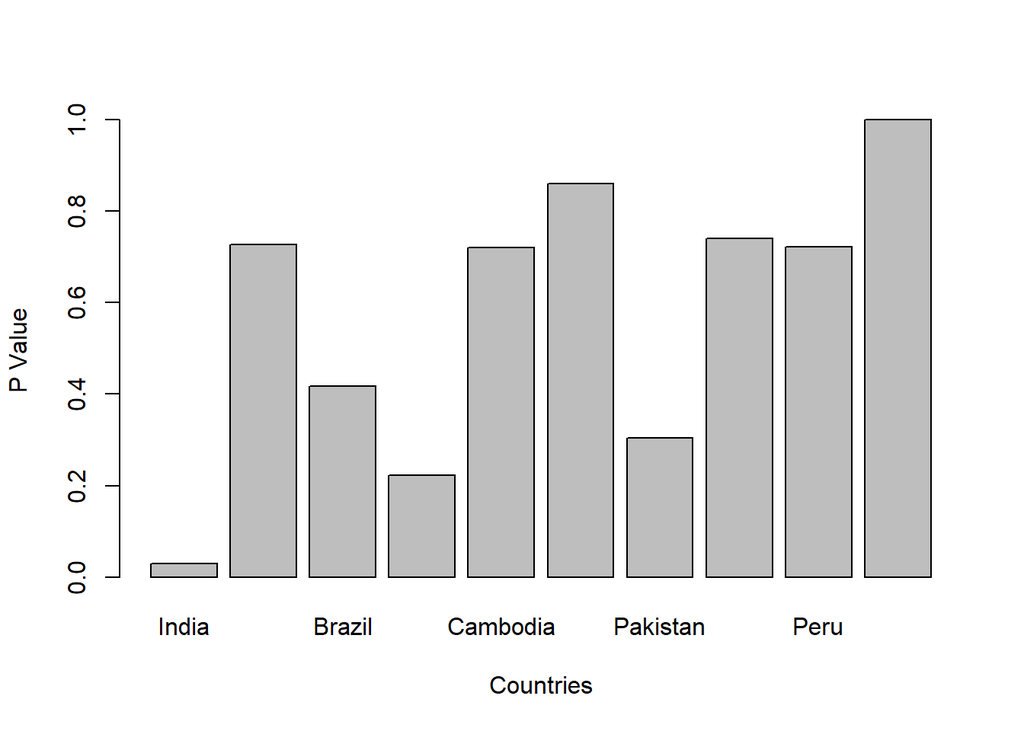

```r
barplot(fin[1:10,], horiz = FALSE, ylab = "P Value", xlab = "Countries")
```

### Problem 5

There is only a significant (p< 0.05) coorelation between GMO use and disease in India.

### Problem 6

I would recommend neither a ban nor moratorium. Proper controls were not used to generate this data, and therefore what we are seeing is a correlation, not a causation.